# A Green-Transition Taxonomy of the EU-27

Vulnerability × potential — and the polarization tension | OPUS project, EU-27

Claudius Gräbner-Radkowitsch

2026-07-14

## The question

*Does the green transition reinforce economic polarization across the EU-27?*

- Two things matter, and they pull apart:
  - **Vulnerability** — how exposed is the current economy?
  - **Potential** — how capable of *green* production?
- Core worry: the transition burden falls on the catch-up East — the countries least able to turn it into green opportunity → convergence stalls, **polarization deepens**

## Where we started — and why it failed

**Naïve approach**

- One Ward clustering
- All per-capita indicators pooled
- Single Euclidean distance

**What came out**

- Just GDP per capita
- Rich North vs poorer East–South
- Nothing new

> Scale dominates → clusters reproduce the known core–periphery split

Need a design that is *income-neutral by construction*.

# The approach

## Design: two vulnerabilities × two potentials

A country’s transition position has two distinct faces — keep them as **separate axes**, not one pooled distance

### Vulnerability

*Transition burden — per value added (income-neutral)*

- Carbon intensity — GHG / value added
- Energy intensity — energy / value added
- Fossil share of primary energy

### Potential

*Green capability*

- Green patents per capita
- **Green Complexity Index (GCI)**
- **Green Complexity Potential (GCP)**

Each block → one **PC1 score** → place EU-27 on a **2-D map**

PC1 = first principal-component score — the single weighted mix of a block’s variables capturing the most shared variation

Data (2014–2018 average): EXIOBASE footprints · Eurostat energy balances · PATSTAT green patents · Atlas HS92 trade

## The key ingredient: green economic complexity

Mealy & Teytelboym (2022) — *what a country can competitively **make green**, not how rich it is*

- Recompute ECI / PCI / **GCI / GCP** from **Atlas HS92** trade (global set, pooled 2014–2018)
- Green HS6 product list (OECD CLEG, 244 codes)
- Extract EU-27

**Validated**

- GCI #1 = Germany · Italy · Austria · Denmark · Czechia …
- reproduces Mealy Fig. 3
- cor(GCI, ECI) = 0.78

GCI is orthogonal to income (R² ≈ 0.01) — adds signal beyond a development ranking.

## The go / no-go check

Before trusting the 2-D map — are the axes *real*, or both GDP in disguise?

**Axes independent**

- cor(vulnerability, potential) = **−0.19**

**Potential ≠ income**

- R² vs log GDP p.c. = **0.07**
- ≤ 0.19 leave-one-out
- Vulnerability *does* track income (R² = 0.50) — read as **substantive**: catch-up economies are more carbon-intensive

✓ Passed → the 2-D structure is **not** reducible to GDP.

# Key results

## The typology map

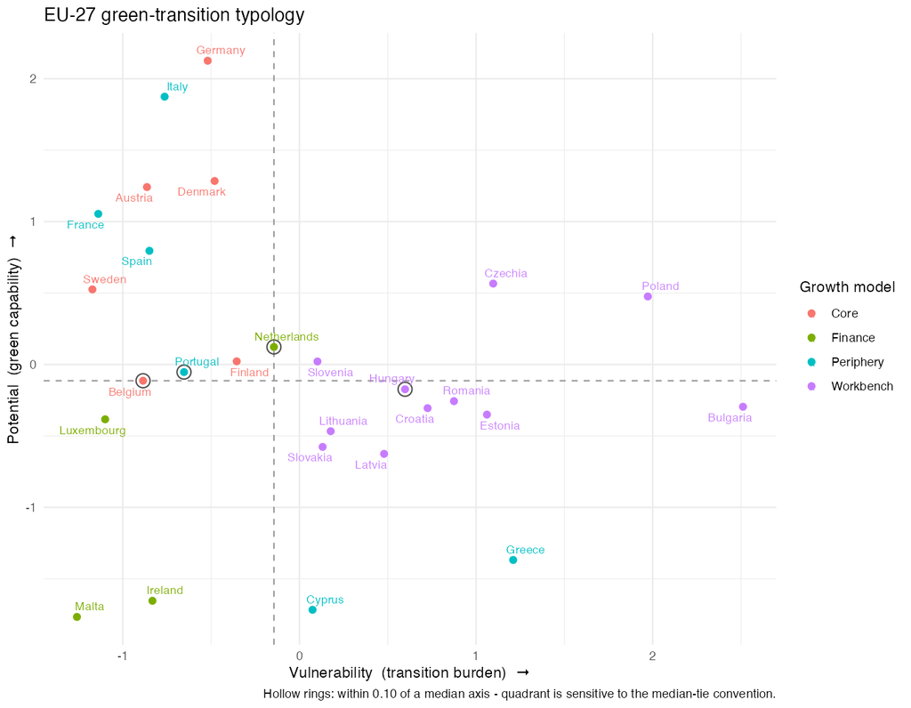

Four quadrants:

- **Winners** — low burden, high capability
- **Exposed but capable**
- **At risk** — high burden, low capability
- **Low-stakes** — low burden, low capability (finance-driven)

Colour = growth model

Growth models (Gräbner et al. 2020, an *independent* classification): **Core** = export-led manufacturing · **Periphery** = demand-led / tourism (South) · **Workbench** = FDI-assembly (East) · **Finance** = financial & tax hubs

## The polarization tension

**Exposed but capable** **CZ · PL · SI · NL**

Carbon-locked *and* green-capable — burden and opportunity on the **same** countries

**At risk** **BG · RO · Baltics · HR · SK · EL · CY · HU**

High burden, low capability — the tail most in need of support

- **Winners** (10): DE DK AT FR SE IT ES FI PT BE
- **Low-stakes**: LU IE MT — rich via finance, not productive activity → little at stake either way
- Catch-up **East** carries the burden — but is *not* uniformly low-potential

## Green complexity flips the income story

- Catch-up **East outranks** high-GDP finance economies on GCI:
  - Czechia, Poland, Hungary, Slovenia
  - **>** Luxembourg, Ireland, Netherlands

> The green *opportunity* is not where the money is.

This is the whole point: a rich/poor axis would have missed it entirely.

# Validation

## External validity

The potential axis predicts *independent* green outcomes — net of GDP p.c.

| Predictor → outcome | Partial correlation |
| --- | --- |
| Potential → renewable share (Eurostat SHARES) | **+0.43** |
| Potential → OECD EPS policy stringency | **+0.42** |
| Vulnerability → renewable share / GDP growth | ≈ 0 (placebo) |

EPS validator covers only 20/27 (OECD members) — silent on the low-potential tail. Validators enter *neither* block → no circularity.

## Consistent with European growth models

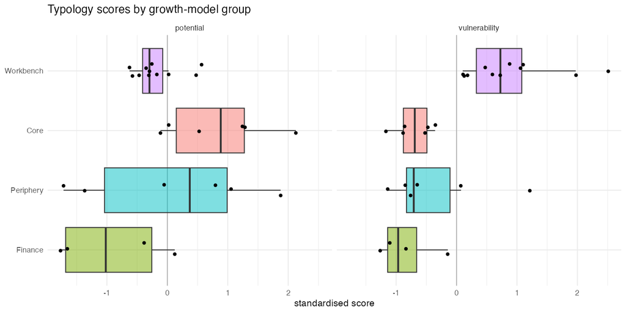

- **Workbench** (catch-up East): vulnerability **+1.60** (p<0.001), potential **−1.03** (p<0.05) vs Core
- Quadrant × growth-model **Cramér’s V = 0.71**
- Matches the prior expectation: catch-up East is more exposed *and* less capable

## Robust

**Barely moves**

- Window shift 2013–17 / 2015–19 → **0 quadrant changes**
- GCI year-to-year rank corr ≥ 0.97
- Survives PCA-vs-mean, variable drops, outlier removal

**Design choices confirmed**

- Only median/MAD rescaling shifts it (patent skew, not green signal)
- Discrete clusters weak (silhouette ≈ 0.28, gap k=1)
- → continuous **map** beats hard clusters

## Where it could break — for discussion

**Measurement**

- Green list = OECD CLEG (244 codes); the authors’ 293-code list may shift GCI
- Green patents skewed toward small states — the one input whose rescaling moves the map
- Vulnerability still tracks income (R² = 0.50): substantive, or residual confound?

**Inference & coverage**

- n = 27 → association indices + Monte-Carlo, not large-sample tests
- Borderline cases on the medians (NL, BE) flip quadrant under the tie convention
- Policy validator (OECD EPS) misses 7/27 — most of the “At risk” tail
- Window ends **2019** (EXIOBASE cap) — not the current decade

## Takeaways

1. An **income-neutral** 2-D taxonomy — vulnerability × potential — that survives the go/no-go test
2. Contribution = a **viable application** of green complexity (Mealy & Teytelboym, not ours) to a new question: *do different growth models face different transition challenges?*
3. They do — **Workbench** East is more exposed *and* less capable → the **polarization** worry: burden on the catch-up group threatens convergence
4. Externally valid, matches growth models, robust to every reasonable spec

For discussion: does the two-axis structure hold?

## Open questions — before we draft

**Framing & claims**

- Descriptive typology *or* test of H1–H3? → write **H1–H3 explicitly**
- GCI: “green complexity” or honestly **green export diversity**? (cor 0.998)
- GCI + GCP both in the block — distinct (held vs not-held) but cor 0.78: state it
- Vulnerability ↔︎ income (R² = 0.50): substantive story *or* confound?
- Register at n = 27 — keep **descriptive**, no significance claims

**Scope & data**

- Green list: ship with OECD CLEG (244) *or* wait for the 293-code list?
- Validation weight: renewables carries it; EPS misses the At-risk tail
- Confirm cuts: brown employment **out** · clustering **illustrative** · window **2014–2018**
- Policy ask: quadrant-based **Cohesion / Just-Transition** targeting?
- Target journal: *Ecological Economics* / *SCED* / *CJE*?

# Appendix

## Why the window ends 2019 — and the cost of moving it

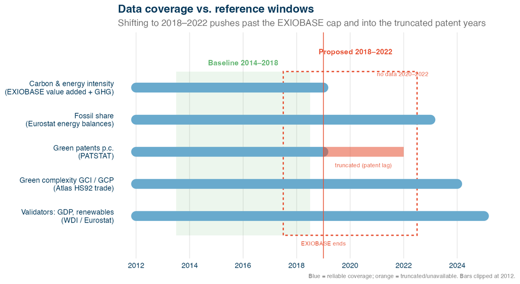

Trade/complexity reaches 2024, but the vulnerability block divides by **EXIOBASE value added (ends 2019)**. A 2018–2022 window overhangs that cap (no footprint for 2020–2022) and leans on **lag-truncated** patent years — so it means *giving up* the consumption-based footprint (→ territorial emissions) and/or the green-patent variable, not just re-dating the map.

## How well one axis summarises each country

Block PC1 explains **61%** (vulnerability) · **62%** (potential) of total variance. Per-country **cos²** = share of a country’s own variation the 1-D score captures.

| Country | Vuln | Pot |
| --- | --- | --- |
| Austria | 98% | 97% |
| Belgium | 85% | 3% |
| Bulgaria | 96% | 28% |
| Croatia | 60% | 28% |
| Cyprus | 0% | 100% |
| Czechia | 88% | 38% |
| Denmark | 9% | 33% |
| Estonia | 39% | 49% |
| Finland | 20% | 0% |
| France | 96% | 93% |
| Germany | 37% | 94% |
| Greece | 49% | 97% |
| Hungary | 44% | 6% |
| Ireland | 52% | 95% |

| Country | Vuln | Pot |
| --- | --- | --- |
| Italy | 82% | 82% |
| Latvia | 16% | 75% |
| Lithuania | 5% | 54% |
| Luxembourg | 94% | 3% |
| Malta | 92% | 93% |
| Netherlands | 1% | 2% |
| Poland | 87% | 34% |
| Portugal | 67% | 1% |
| Romania | 58% | 19% |
| Slovakia | 4% | 65% |
| Slovenia | 5% | 0% |
| Spain | 91% | 40% |
| Sweden | 94% | 26% |

Low cos² = the country sits near the origin / a median, so the single axis represents it poorly — exactly the borderline cases (Netherlands 1/2%, Slovenia, Finland). It flags *where to read the map cautiously*, not a model failure.

## Forward look: does 2014–18 predict 2018–23?

*Exploratory — freeze the baseline map, test it against outcomes that never entered the scores.*

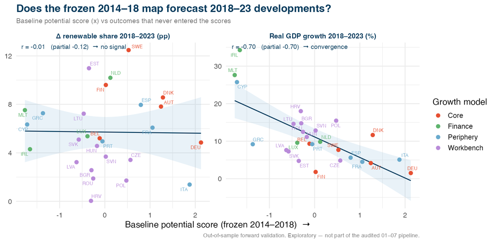

**Green capability ≠ renewable deployment** (no signal, left) — but low-potential catch-up economies **grew faster** (convergence, net of income, right). Incomes converge while the green-capability ordering persists: the polarization question, dynamically. Vulnerability axis not shown — EXIOBASE ends 2019, so only *potential* is trackable past 2018.

## Green-capability catch-up? Barely

*Exploratory — recompute green complexity for 2019–23 (same Atlas method) vs the 2014–18 baseline.*

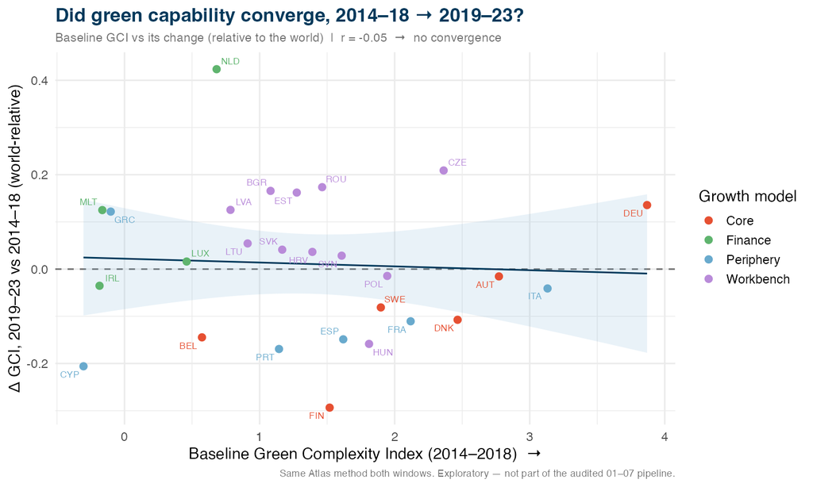

r(baseline GCI, ΔGCI) = **−0.05** → **no convergence**: capability rankings are sticky over 5 years. Workbench East **+0.08** vs Core **−0.08** (world-relative) — a nudge, not catch-up; NLD the one real mover. Complements the forward-look: incomes converged, green capability did not.

## The map moves on one axis only

*Exploratory — vulnerability here is a **territorial proxy** (GHG + energy per GDP, fossil share) built to be comparable across time; not the paper’s consumption-based per-VA axis.*

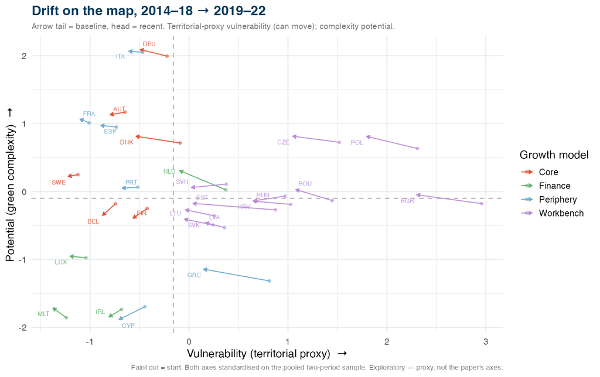

Almost every arrow points **left** — all decarbonising, the exposed East (PL, BG, RO, CZ) fastest — but arrows are ~**horizontal**: potential barely moves. **Burden gap narrows, capability gap persists.** Caveat: 2019–22 spans COVID + the energy crisis → partly cyclical, not structural.

## Data we considered — for discussion

**Wind/solar geophysical potential** *(JRC ENSPRESO)*

- Natural **endowment**, not economic structure or capability → a *different* axis
- Risk: re-imports geographic determinism (sunbelt), silent on production polarization
- Better as an **external validator** or a separate “endowment” layer to *interpret* the map — not a block input

**Fossil production / consumption p.c.** *(EU Energy Atlas)*

- **Consumption p.c.** = a *level* → tracks GDP p.c. → re-imports the income/scale confound we removed. Skip (or descriptive only)
- **Production p.c.** = distinct (extraction / stranded-asset exposure), *not* redundant with fossil-share-of-mix — but thin EU coverage; test overlap first → robustness, not core